# Econometrics R Manual

Roman Sigalov

8 August 2016

### Introduction

R reminds much more of a traditional programming language when compared to STATA. Hence its capabilities are much bigger and econometrics is not the only subject where you can use it. It is widely used among researches including economists, in data science, machine learning and other fields. One of the best things about R is that it is FREE and OPEN-SOURCE which mean that if you prefer R to STATA you get (1) great variety of packages capable of doing almost anything and (2) enormous community (on such platforms as stackexchange) which is able to give you an answer on virtually every question. So, if decide to use R during this semester, you are more than welcome to ask help from me, but I strongly encourage you to google your question first, after all, this is the way that even experienced programmist work, they google.

However, there are drawbacks in using R. The most important (and some may say that the only one) is that its learning curve is very steep. It is hard to start programming in R, understand how the function work and how to deal with new problems. The second thing is that its function are limited out-of-the-box and you need to download additional packages if you want to have more functionality.

In this tutorial, which I will be updating on a constant basis, I will explain how to do everything that Konstantin is doing in STATA as well as some specific things about this language and overview of an incredibly powerful plotting package called “ggplot2”.

### Basics

Here we will cover the main features of R that are not related to econometrics. We will cover basic data types, how to do basic operations and some trickier stuff that you will need in the future.

### Data.

Here I will explain how to get data into R. Both from local computer in different formats as well as from the web.

### Loops, conditional statements and other.

### Packages

Here I will highlight several packages that are very useful for data analysis and for your econometrics class as well. Some of them may do things that will be required later in the semester. So, if you do not understand yet what is Newey-West errors don’t bother, you will catch up later.

Almost every package that you will need are stored in so called The Comprehensive R Archive Network (CRAN). It means that you can simply install them by typing

```r
install.packages("ggplot2")
```

in R-console or RStudio. Lets list the packages that are either important for the course or give some interesting new function.

```r
library("sandwich")
```

is able to compute various kinds of standard errors including, White (Heteroskedasticity consistent errors, hence HC) and Newey-West (Heteroskedasticity and Autocorrelation Consistent errors, hence HAC).

```r
library("ggplot2")
library("ggthemes")
```

first is able to plot almost anything you will every need to plot. Second adds additional themes to ggplot: you can make you graph look like The Economist Graph, WSJ or even STATA graph.

```r
library("sqldf")
```

allows you to manipulate data using SQLite language. If you you know SQL well it will probably become your favorite package. Otherwise, I will either show you how to do some stuff in it, or you may not bother much

```r
library("reshape")
```

```r
library("DataCombine")
```

allows you to easily create lags for you regression

```r
library("xts")
```

additional capabilities for time series data manipulation, will be covered later. Below you can find other interesting packages.

```r
library("stargazer")
```

allows you to export regression results into LaTeX format.

```r
library("TTR") # for rolling volatility
library("lubridate") # for operations on dates
library("ghyp")
library("MASS")
library("xts")
library("memisc")
library("grid") # for arranging plots in grid
library("psych")
library("FinTS") # For GARCH regressions
library("fGarch")
```

### Regressions I. Basics

We are going to use data from CRSP and study companys’ cash balances and what affects them. Let’s import data and look what columns do we need:

```r
setwd("~")
data <- read.csv("/Users/rsigalov/Documents/7Semester/R\ Econometrics\ Handbook/CRSP_data.csv", sep = ";")
colnames(data)
```

```
##  [1] "GVKEY"               "DATADATE"            "SIC"
##  [4] "AT"                  "CHE"                 "DLC"
##  [7] "DLTT"                "SEQ"                 "WCAP"
## [10] "DVC"                 "OIBDP"               "SALE"
## [13] "TXT"                 "XINT"                "XRD"
## [16] "AQC"                 "CAPX"                "CSHO"
## [19] "PRCC_F"              "market_to_book"      "log_firm_size"
## [22] "cf"                  "nwc"                 "capex"
## [25] "leverage"            "div"                 "rd_to_sales"
## [28] "sic_2"               "ind_cf_vol"          "ind_cf_no_level_vol"
## [31] "cash"                "log_cash"            "aqc_to_asset"
## [34] "year"
```

Let’s first estimate regression: $cash_i = \beta_0 + \beta_1ind\_cf\_vol_i + \varepsilon_i$ since volatility of cash flow of the industry ($ind\_cf\_vol$) may be positively related to the cash that the firm wants to hold to absorb risks. Use command summary to print the output of the regression:

```r
model <- lm(data = data, cash ~ ind_cf_vol)
summary(model)
```

```
##
## Call:
## lm(formula = cash ~ ind_cf_vol, data = data)
##
## Residuals:
##      Min       1Q   Median       3Q      Max
## -0.43348 -0.12046 -0.04927  0.07161  0.77684
##
## Coefficients:
##             Estimate Std. Error t value Pr(>|t|)
## (Intercept)  0.03463    0.00576   6.013 1.99e-09 ***
## ind_cf_vol   2.53310    0.08101  31.270  < 2e-16 ***
## ---
## Signif. codes:  0 '***' 0.001 '**' 0.01 '*' 0.05 '.' 0.1 ' ' 1
##
## Residual standard error: 0.2045 on 4071 degrees of freedom
##   (535 observations deleted due to missingness)
## Multiple R-squared:  0.1937, Adjusted R-squared:  0.1935
## F-statistic: 977.8 on 1 and 4071 DF,  p-value: < 2.2e-16
```

The object that `summary()` command creates contains a lot of useful information. For example:

```r
sum <- summary(model)
sum$coefficients # outputs a matrix
```

```
##               Estimate  Std. Error   t value      Pr(>|t|)
## (Intercept) 0.03463513 0.005760495  6.012526  1.986903e-09
## ind_cf_vol  2.53310493 0.081007696 31.269929 1.441064e-192
```

```r
sum$r.squared
```

```
## [1] 0.1936711
```

```r
sum$fstatistic
```

```
##     value     numdf     dendf
##  977.8085    1.0000 4071.0000
```

Using coefficients we can manually predict cash balance:

```r
beta_0 <- sum$coefficients[1,1]
beta_1 <- sum$coefficients[2,1]
ind_cf_vol_1 <- 0.05
beta_0 + beta_1 * ind_cf_vol_1
```

```
## [1] 0.1612904
```

But, of course, we can predict easier using our model object:

```r
predict(model, newdata = (ind_cf_vol = 0.05))
```

```
##         1
## 0.1612904
```

or we can do it for several points (but we need to insert dataframe)

```r
predict(model, newdata = data.frame(ind_cf_vol = c(0.05, 0.06, 0.07, 0.08)))
```

```
##         1         2         3         4
## 0.1612904 0.1866214 0.2119525 0.2372835
```

and add confidence interval

```r
predict(model, newdata = data.frame(ind_cf_vol = c(0.05, 0.06, 0.07, 0.08)), interval = "confidence")
```

```
##         fit       lwr       upr
## 1 0.1612904 0.1548442 0.1677365
## 2 0.1866214 0.1803375 0.1929053
## 3 0.2119525 0.2054358 0.2184692
## 4 0.2372835 0.2301778 0.2443893
```

Let’s plot our results using ggplot (in more details it will be explained in the next part):

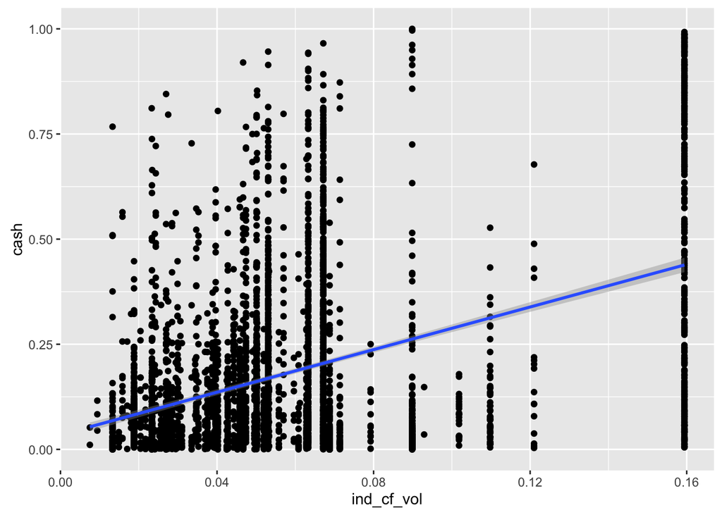

```r
library("ggplot2")
ggplot(data = data, aes(x = ind_cf_vol, y = cash)) +
  geom_point() +
  geom_smooth(method = "lm", se = TRUE) # fitting a line
```

Fitting multivariate regression and prediction is just as simple:

```r
model2 <- lm(data = data, cash ~ ind_cf_vol + rd_to_sales)
predict(model2,
        newdata = data.frame(ind_cf_vol = c(0.05, 0.06),
                             rd_to_sales = c(0.3, 0.45)),
        interval = "confidence")
```

```
##         fit       lwr       upr
## 1 0.1710242 0.1651791 0.1768694
## 2 0.1950629 0.1892911 0.2008347
```

```r
library("stargazer")
```

### Plotting. Introduction to ggplot2.

`ggplot2` is a wonderful package which will help you to create beautiful graphs. It can be tricky at first but as your demands will grow it will become indisensible. First let’s create simple graph without ggplot, because it is easier to do it this way.

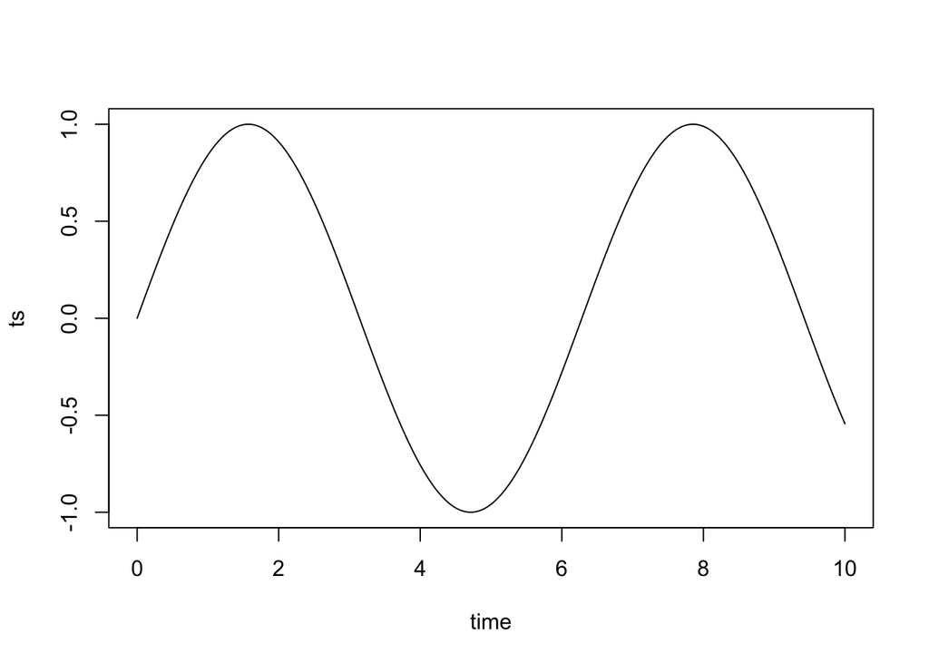

```r
time <- seq(0,10,0.01)
ts <- sapply(time, sin)
plot(x = time, y = ts, type = "l")
```

`sapply` is a very powerful function, it takes vector (in our case `time`) and applies function `sin` elementwise. If you will create your own function you can use it as well. For example:

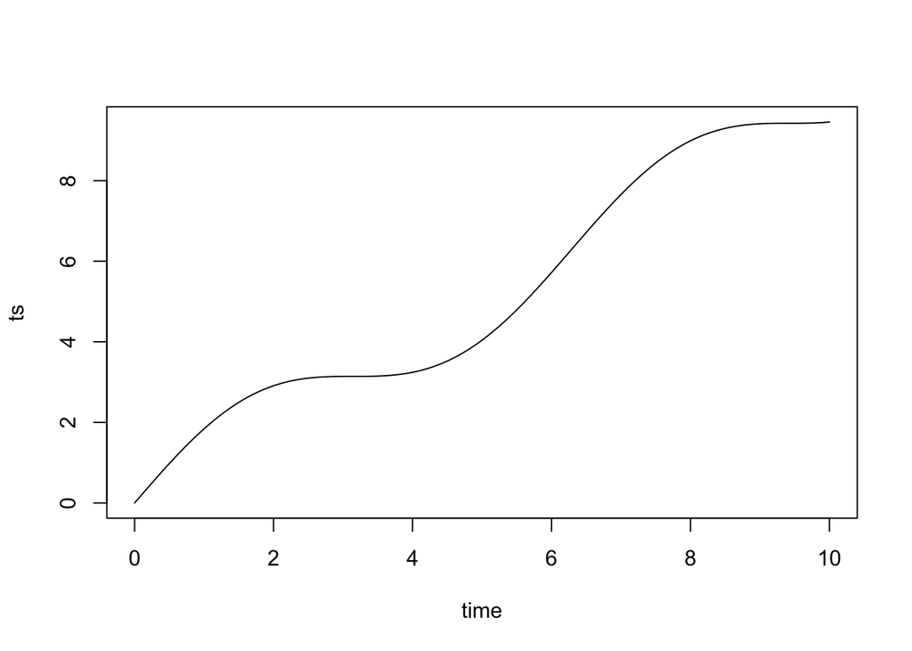

```r
time <- seq(0,10,0.01)
func <- function(x) {sin(x) + x}
ts <- sapply(time, func)
plot(x = time, y = ts, type = "l")
```

`ggplot` is definitely worse in plotting such data. Hence, I will show how to use it for more complicated datasets with a lot of variables that we want to somehow represent.

I have two datasets which represent results of backtesting of a trading strategy. First file contains parameters on the beginning of the backtest, second file on the end.

```r
setwd("~")
first <- read.csv("/Users/rsigalov/Documents/7Semester/R\ Econometrics\ Handbook/EURUSD_first.csv", sep = ";")
last <- read.csv("/Users/rsigalov/Documents/7Semester/R\ Econometrics\ Handbook/EURUSD_last.csv", sep = ";")
colnames(first)
```

```
##  [1] "Day"              "Date"             "Spot"
##  [4] "Vol"              "Rate"             "Hedge"
##  [7] "Rehedge_Value"    "Option_Value"     "Interpolated_Vol"
## [10] "Delta"            "Maturity"         "Forward"
## [13] "Hedge_Position"   "Stock_Position"   "Trading_Gain"
## [16] "Position_Value"   "Acc_Trading_Gain" "Trades"
## [19] "Hedge_name"       "Scenario"         "Scenario_Group"
## [22] "Hedge_Type"       "Day_Type"
```

I will do some manipulations with these files using `sql` language and show which columns do we have:

```r
library("sqldf")
stats <- sqldf("
select
  f.Scenario_Group as scenario_group,
  f.Scenario as scenario,
  l.Spot - f.Spot as spot_chg,
  l.Position_Value + l.Acc_Trading_Gain - f.Option_Value as position_value_chg,
  l.Trades as trades,
  l.Option_Value - f.Option_Value as option_chg
from last as l
  left join first as f on f.Scenario = l.Scenario and f.Scenario_Group = l.Scenario_Group
               ")
colnames(stats)
```

```
## [1] "scenario_group"     "scenario"           "spot_chg"
## [4] "position_value_chg" "trades"             "option_chg"
```

We have different scenario groups and different scenarios. First, let’s plot change in position value against change in spot price of asset:

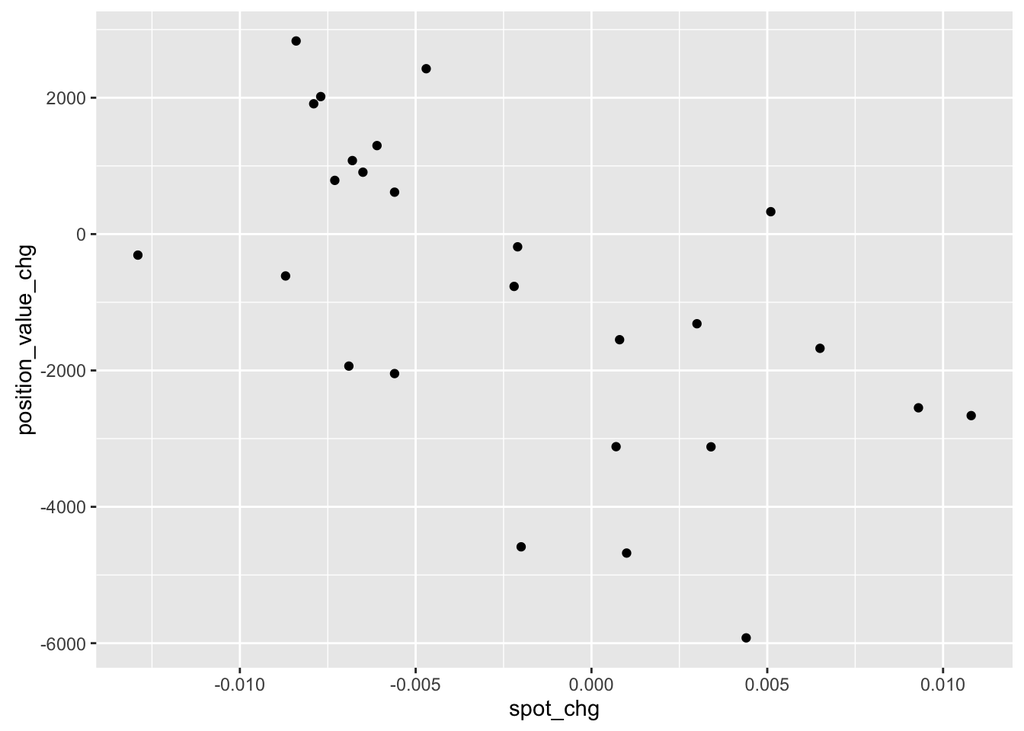

```r
library("ggplot2")
ggplot(stats[stats$scenario_group == 160,], aes(x = spot_chg, y = position_value_chg)) +
  geom_point()
```

However, we might want to show different groups we can do it by adding color into aes with which will depend on group:

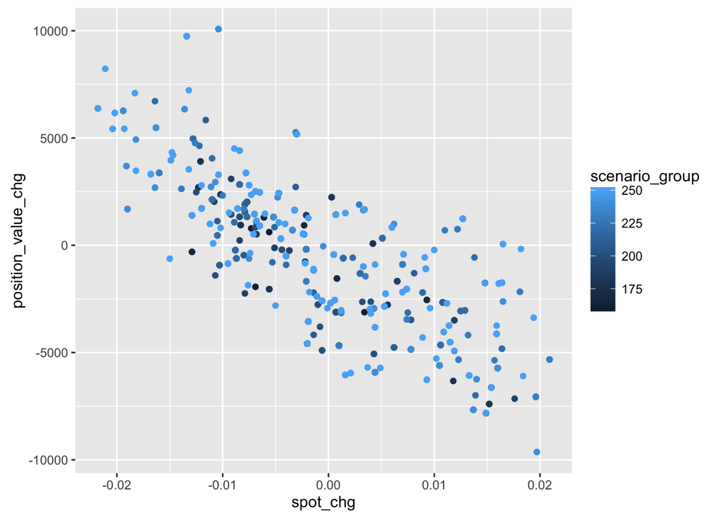

```r
ggplot(stats, aes(x = spot_chg, y = position_value_chg, color = scenario_group)) +
  geom_point()
```

ggplot suggested to use continuous scale for our groups, however, they are discrete and we can specify it by adding `factor()` around `scenario_group`:

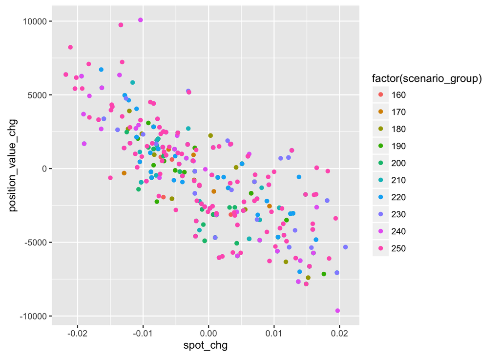

```r
ggplot(stats, aes(x = spot_chg, y = position_value_chg, color = factor(scenario_group))) +
  geom_point()
```

It looks like a mess, maybe it is better give each group a separate point type:

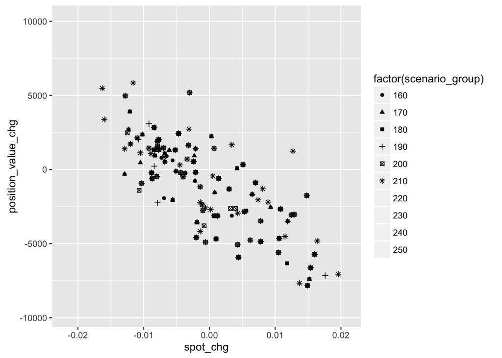

```r
ggplot(stats, aes(x = spot_chg, y = position_value_chg, shape = factor(scenario_group))) +
  geom_point()
```

Well, there are not such as many point types. We can separate each group into seprate graph:

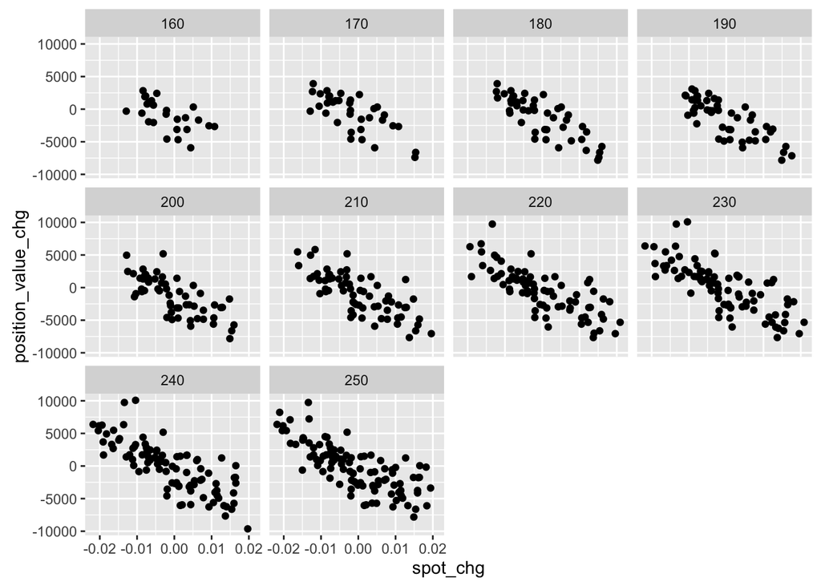

```r
stats$scenario_group <- as.character(stats$scenario_group)
ggplot(stats, aes(x = spot_chg, y = position_value_chg)) +
  geom_point() +
  facet_wrap(~scenario_group)
```

Above I converted scenario_group column in character format from numerical, to avoid using `factor()`, for some reasons it doesn’t work in facet. Of course, we can do not only points, but also lines. Below, I will show several examples. I have the following data:

```r
price_data <- read.csv("/Users/rsigalov/Documents/7Semester/R\ Econometrics\ Handbook/price_dynamics.csv", sep = ",")
colnames(price_data)
```

```
##  [1] "X"           "sigma_s"     "sigma_e"     "theta"       "k_d"
##  [6] "lambda"      "lambda_real" "v_bar"       "time"        "price"
## [11] "price_cond"  "k_tilde"
```

```r
unique(price_data$sigma_e)
```

```
## [1] 0.50 0.75 1.00 1.25 1.50
```

```r
unique(price_data$k_d)
```

```
## [1] 0.50 0.75 1.00 1.25 1.50
```

```r
unique(price_data$lambda)
```

```
## [1] 0.50 0.75 1.00 1.25 1.50
```

Let’s first pick some values for `sigma_e`, `k_d` and `lambda`. I want to plot `price` against `time` and want to distinguish whether `price_cond` was above or below zero.

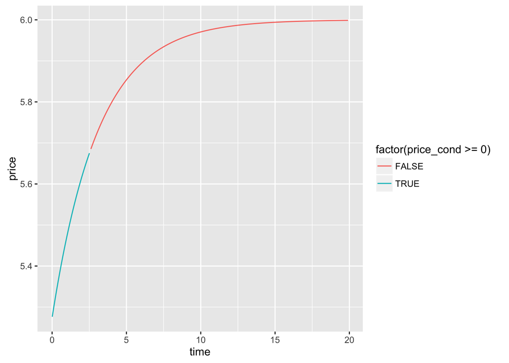

```r
price_data_sub <- price_data[price_data$sigma_e==1 & price_data$k_d==1 & price_data$lambda==1,]
ggplot(price_data_sub, aes(x = time, y = price, color = factor(price_cond >= 0))) +
  geom_line()
```

Now I want to add different lines types for values of `lambda` (here we need to use `factor()` again):

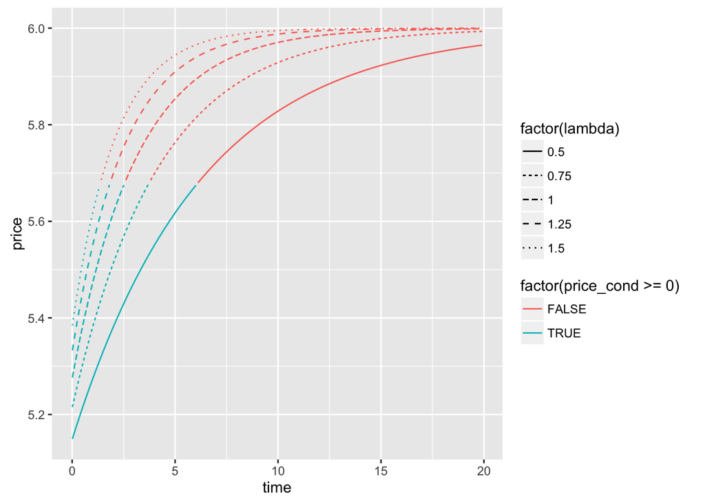

```r
price_data_sub <- price_data[price_data$sigma_e==1 & price_data$k_d==1,]
ggplot(price_data_sub, aes(x = time, y = price, color = factor(price_cond >= 0), linetype = factor(lambda))) +
  geom_line()
```

and then we can make a grid with horizontal separation by `k_d` and vertical by `sigma_e`:

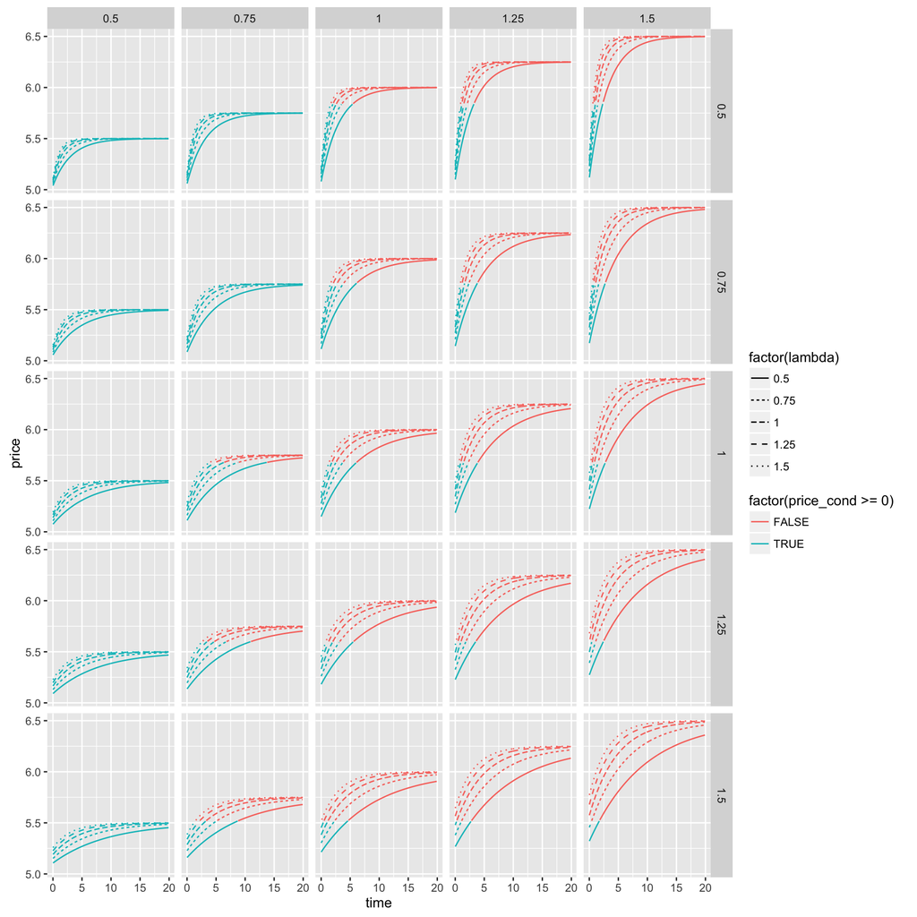

```r
ggplot(price_data, aes(x = time, y = price, color = factor(price_cond >= 0), linetype = factor(lambda))) +
  geom_line() +
  facet_grid(sigma_e ~ k_d)
```

Using combinations of facetting, linetype, linecolors you can show various proprties of a data on one single plot. This is just basics of `ggplot` I will include chapter on additional features later on. Meanwhile you can use this cheatsheet https://www.rstudio.com/wp-content/uploads/2015/03/ggplot2-cheatsheet.pdf which is really helpful.

### Regressions II. Standard Errors

Here I will show how to change standard errors as well as how to manipulate variance-covariance matrices and other important stuff. I will give you several examples of how to build confidence intervals and make graphs clearly representing your point.

Let’s continue to work with our previous example and subset data to include only one year. Use `unique()` function to select only inique values from a vector:

```r
unique(data$year) # Determining which years there are
```

```
## [1] 2015 2016
```

```r
data2016 <- subset(x = data, year == 2016)
```

Since we might expect that each error are different for each firm we might want to use White standard errors. Using package `sandwich` we can estimate Heteroskedasticity consistent variance-covariance matrix:

```r
library("sandwich")
model <- lm(data = data, cash ~ ind_cf_vol + rd_to_sales)
vcovHC(model) # Variance convariance matrix
```

```
##               (Intercept)    ind_cf_vol   rd_to_sales
## (Intercept)  2.608018e-05 -0.0004258878  4.315199e-06
## ind_cf_vol  -4.258878e-04  0.0095383263 -1.198015e-04
## rd_to_sales  4.315199e-06 -0.0001198015  1.586688e-05
```

```r
diag(vcovHC(model)) # Diagonal elements of VCOV
```

```
##  (Intercept)   ind_cf_vol  rd_to_sales
## 2.608018e-05 9.538326e-03 1.586688e-05
```

```r
sqrt(diag(vcovHC(model))) # standard errors
```

```
## (Intercept)  ind_cf_vol rd_to_sales
## 0.005106876 0.097664355 0.003983326
```

We can then test the coefficients using new errors using package `lmtest` and save these errors for subsequent use, for example, to export to LaTeX:

```r
library("lmtest")
coeftest(model, vcov = vcovHC(model))
```

```
##
## t test of coefficients:
##
##              Estimate Std. Error t value  Pr(>|t|)
## (Intercept) 0.0836461  0.0051069  16.379 < 2.2e-16 ***
## ind_cf_vol  1.3100239  0.0976644  13.414 < 2.2e-16 ***
## rd_to_sales 0.0729232  0.0039833  18.307 < 2.2e-16 ***
## ---
## Signif. codes:  0 '***' 0.001 '**' 0.01 '*' 0.05 '.' 0.1 ' ' 1
```

```r
model_se <- sqrt(diag(vcovHC(model)))
```

Later you will need to use Heteroskedasticity and Autocorrelation consistent standard error (or Newey-West standard errors) which can be evaluated using the same way and function `vcovHAC()`.

### Regressions III. Transformatin of variables

Here I will show you how to transform your variables to perform log-linear, linear-log, log-log, power and other regressions. First, you can always add another variable to the dataset and oridary regression:

```r
data$log_rd_to_sales <- log(data$rd_to_sales)
head(data$log_rd_to_sales)
```

```
## [1]      -Inf      -Inf      -Inf      -Inf -4.729433      -Inf
```

There are a lot of zeros, thus we need to exclude such observations in order to perform log regression:

```r
data_tmp <- data[data$rd_to_sales != 0, ]
data_tmp$log_rd_to_sales <- log(data_tmp$rd_to_sales)
model <- lm(data = data_tmp, formula = cash ~ ind_cf_vol + log_rd_to_sales)
```

or you can simply specify it in the `lm()` function to create different kind of regressions:

```r
model <- lm(data = data_tmp, formula = cash ~ ind_cf_vol + log(rd_to_sales)) # linear-log
model <- lm(data = data_tmp, formula = log(cash) ~ ind_cf_vol + rd_to_sales) # log-linear
model <- lm(data = data_tmp, formula = log(cash) ~ ind_cf_vol + log(rd_to_sales)) # log-log
```

In order to perform, for example, quadratic regression, we may again create additional variable:

```r
data$ind_cf_vol_sqr <- (data$ind_cf_vol)^2
model <- lm(data = data, formula = cash ~ ind_cf_vol + ind_cf_vol_sqr)
```

or make the transformation inside `lm()` function using `I()`. You can add different transformation of the same variable (for example for fitting $y = \beta_0 + \beta_1 x + \beta_2 x^2$ using `I()` as well:

```r
model <- lm(data = data, formula = cash ~ ind_cf_vol + I(ind_cf_vol^2))
model <- lm(data = data, formula = cash ~ ind_cf_vol + I(ind_cf_vol^2) + I(ind_cf_vol^3))
```

### Tables

Here I will show you how to create LaTeX tables for your descriptive statistics and other

### Regressions IV. F-statistics

Here I will show how to compute F-statistics.

### Regressions V. Probit and Logit

Have you heard of neural networks? If you did and want to understand how they are working you first need to get Probit and Logit.

### Plotting. More advanced ggplot2.

### Dates, dates, dates…

Working with dates is the most difficult part of data analysis, they are so unstandartised.

### Regressions VI. Panel data

### Regressions VII. Instrumental Variables and their friends

### Regressions VIII. Time Series

### Some Machine Learning for Prediction